# Risk Factor Analysis

## Outcome Variable

**Outcome Variable:** haz

## Predictor Variables

**Intervention Variable:** predfeed36

**Adjustment Set:**

- arm
- sex
- month
- brthmon
- W_mage
- meducyrs
- feducyrs
- hhwealth_quart
- hfoodsec
- W_mhtcm
- vagbrth
- W_gagebrth
- W_birthwt
- W_birthlen
- W_nrooms
- W_nchldlt5
- W_parity
- impfloor
- impsan
- safeh20
- delta_W_mage
- delta_meducyrs
- delta_feducyrs
- delta_hhwealth_quart
- delta_hfoodsec
- delta_W_mhtcm
- delta_vagbrth
- delta_W_gagebrth
- delta_W_birthwt
- delta_W_birthlen
- delta_W_nrooms
- delta_W_nchldlt5
- delta_W_parity
- delta_impfloor
- delta_impsan
- delta_safeh20

## Stratifying Variables

The analysis was stratified on these variable(s):

- agecat
- studyid
- country

## Data Summary

| agecat | studyid | country | predfeed36 | n_cell | n |
| --- | --- | --- | --- | --- | --- |
| Birth | ki0047075b-MAL-ED | BANGLADESH | 1 | 125 | 243 |
| Birth | ki0047075b-MAL-ED | BANGLADESH | 0 | 118 | 243 |
| Birth | ki0047075b-MAL-ED | BRAZIL | 1 | 29 | 185 |
| Birth | ki0047075b-MAL-ED | BRAZIL | 0 | 156 | 185 |
| Birth | ki0047075b-MAL-ED | INDIA | 1 | 16 | 198 |
| Birth | ki0047075b-MAL-ED | INDIA | 0 | 182 | 198 |
| Birth | ki0047075b-MAL-ED | NEPAL | 1 | 26 | 172 |
| Birth | ki0047075b-MAL-ED | NEPAL | 0 | 146 | 172 |
| Birth | ki0047075b-MAL-ED | PERU | 1 | 118 | 273 |
| Birth | ki0047075b-MAL-ED | PERU | 0 | 155 | 273 |
| Birth | ki0047075b-MAL-ED | SOUTH AFRICA | 1 | 3 | 236 |
| Birth | ki0047075b-MAL-ED | SOUTH AFRICA | 0 | 233 | 236 |
| Birth | ki0047075b-MAL-ED | TANZANIA, UNITED REPUBLIC OF | 1 | 1 | 121 |
| Birth | ki0047075b-MAL-ED | TANZANIA, UNITED REPUBLIC OF | 0 | 120 | 121 |
| Birth | ki1000109-EE | PAKISTAN | 1 | 1 | 2 |
| Birth | ki1000109-EE | PAKISTAN | 0 | 1 | 2 |
| Birth | kiGH5241-JiVitA-3 | BANGLADESH | 1 | 11176 | 13946 |
| Birth | kiGH5241-JiVitA-3 | BANGLADESH | 0 | 2770 | 13946 |
| Birth | kiGH5241-JiVitA-4 | BANGLADESH | 1 | 582 | 727 |
| Birth | kiGH5241-JiVitA-4 | BANGLADESH | 0 | 145 | 727 |
| 6 months | ki0047075b-MAL-ED | BANGLADESH | 1 | 129 | 240 |
| 6 months | ki0047075b-MAL-ED | BANGLADESH | 0 | 111 | 240 |
| 6 months | ki0047075b-MAL-ED | BRAZIL | 1 | 37 | 209 |
| 6 months | ki0047075b-MAL-ED | BRAZIL | 0 | 172 | 209 |
| 6 months | ki0047075b-MAL-ED | INDIA | 1 | 19 | 236 |
| 6 months | ki0047075b-MAL-ED | INDIA | 0 | 217 | 236 |
| 6 months | ki0047075b-MAL-ED | NEPAL | 1 | 32 | 236 |
| 6 months | ki0047075b-MAL-ED | NEPAL | 0 | 204 | 236 |
| 6 months | ki0047075b-MAL-ED | PERU | 1 | 126 | 271 |
| 6 months | ki0047075b-MAL-ED | PERU | 0 | 145 | 271 |
| 6 months | ki0047075b-MAL-ED | SOUTH AFRICA | 1 | 3 | 254 |
| 6 months | ki0047075b-MAL-ED | SOUTH AFRICA | 0 | 251 | 254 |
| 6 months | ki0047075b-MAL-ED | TANZANIA, UNITED REPUBLIC OF | 1 | 2 | 247 |
| 6 months | ki0047075b-MAL-ED | TANZANIA, UNITED REPUBLIC OF | 0 | 245 | 247 |
| 6 months | ki1000109-EE | PAKISTAN | 1 | 222 | 367 |
| 6 months | ki1000109-EE | PAKISTAN | 0 | 145 | 367 |
| 6 months | ki1000304b-SAS-FoodSuppl | INDIA | 1 | 0 | 168 |
| 6 months | ki1000304b-SAS-FoodSuppl | INDIA | 0 | 168 | 168 |
| 6 months | ki1113344-GMS-Nepal | NEPAL | 1 | 423 | 526 |
| 6 months | ki1113344-GMS-Nepal | NEPAL | 0 | 103 | 526 |
| 6 months | ki1148112-LCNI-5 | MALAWI | 1 | 47 | 272 |
| 6 months | ki1148112-LCNI-5 | MALAWI | 0 | 225 | 272 |
| 6 months | kiGH5241-JiVitA-3 | BANGLADESH | 1 | 10705 | 13375 |
| 6 months | kiGH5241-JiVitA-3 | BANGLADESH | 0 | 2670 | 13375 |
| 6 months | kiGH5241-JiVitA-4 | BANGLADESH | 1 | 3256 | 4171 |
| 6 months | kiGH5241-JiVitA-4 | BANGLADESH | 0 | 915 | 4171 |
| 24 months | ki0047075b-MAL-ED | BANGLADESH | 1 | 117 | 211 |
| 24 months | ki0047075b-MAL-ED | BANGLADESH | 0 | 94 | 211 |
| 24 months | ki0047075b-MAL-ED | BRAZIL | 1 | 30 | 169 |
| 24 months | ki0047075b-MAL-ED | BRAZIL | 0 | 139 | 169 |
| 24 months | ki0047075b-MAL-ED | INDIA | 1 | 18 | 227 |
| 24 months | ki0047075b-MAL-ED | INDIA | 0 | 209 | 227 |
| 24 months | ki0047075b-MAL-ED | NEPAL | 1 | 30 | 228 |
| 24 months | ki0047075b-MAL-ED | NEPAL | 0 | 198 | 228 |
| 24 months | ki0047075b-MAL-ED | PERU | 1 | 94 | 200 |
| 24 months | ki0047075b-MAL-ED | PERU | 0 | 106 | 200 |
| 24 months | ki0047075b-MAL-ED | SOUTH AFRICA | 1 | 3 | 238 |
| 24 months | ki0047075b-MAL-ED | SOUTH AFRICA | 0 | 235 | 238 |
| 24 months | ki0047075b-MAL-ED | TANZANIA, UNITED REPUBLIC OF | 1 | 2 | 214 |
| 24 months | ki0047075b-MAL-ED | TANZANIA, UNITED REPUBLIC OF | 0 | 212 | 214 |
| 24 months | ki1113344-GMS-Nepal | NEPAL | 1 | 369 | 456 |
| 24 months | ki1113344-GMS-Nepal | NEPAL | 0 | 87 | 456 |
| 24 months | ki1148112-LCNI-5 | MALAWI | 1 | 34 | 189 |
| 24 months | ki1148112-LCNI-5 | MALAWI | 0 | 155 | 189 |
| 24 months | kiGH5241-JiVitA-3 | BANGLADESH | 1 | 5293 | 6693 |
| 24 months | kiGH5241-JiVitA-3 | BANGLADESH | 0 | 1400 | 6693 |
| 24 months | kiGH5241-JiVitA-4 | BANGLADESH | 1 | 3153 | 4023 |
| 24 months | kiGH5241-JiVitA-4 | BANGLADESH | 0 | 870 | 4023 |

The following strata were considered:

- agecat: 24 months, studyid: ki0047075b-MAL-ED, country: BANGLADESH
- agecat: 24 months, studyid: ki0047075b-MAL-ED, country: BRAZIL
- agecat: 24 months, studyid: ki0047075b-MAL-ED, country: INDIA
- agecat: 24 months, studyid: ki0047075b-MAL-ED, country: NEPAL
- agecat: 24 months, studyid: ki0047075b-MAL-ED, country: PERU
- agecat: 24 months, studyid: ki0047075b-MAL-ED, country: SOUTH AFRICA
- agecat: 24 months, studyid: ki0047075b-MAL-ED, country: TANZANIA, UNITED REPUBLIC OF
- agecat: 24 months, studyid: ki1113344-GMS-Nepal, country: NEPAL
- agecat: 24 months, studyid: ki1148112-LCNI-5, country: MALAWI
- agecat: 24 months, studyid: kiGH5241-JiVitA-3, country: BANGLADESH
- agecat: 24 months, studyid: kiGH5241-JiVitA-4, country: BANGLADESH
- agecat: 6 months, studyid: ki0047075b-MAL-ED, country: BANGLADESH
- agecat: 6 months, studyid: ki0047075b-MAL-ED, country: BRAZIL
- agecat: 6 months, studyid: ki0047075b-MAL-ED, country: INDIA
- agecat: 6 months, studyid: ki0047075b-MAL-ED, country: NEPAL
- agecat: 6 months, studyid: ki0047075b-MAL-ED, country: PERU
- agecat: 6 months, studyid: ki0047075b-MAL-ED, country: SOUTH AFRICA
- agecat: 6 months, studyid: ki0047075b-MAL-ED, country: TANZANIA, UNITED REPUBLIC OF
- agecat: 6 months, studyid: ki1000109-EE, country: PAKISTAN
- agecat: 6 months, studyid: ki1000304b-SAS-FoodSuppl, country: INDIA
- agecat: 6 months, studyid: ki1113344-GMS-Nepal, country: NEPAL
- agecat: 6 months, studyid: ki1148112-LCNI-5, country: MALAWI
- agecat: 6 months, studyid: kiGH5241-JiVitA-3, country: BANGLADESH
- agecat: 6 months, studyid: kiGH5241-JiVitA-4, country: BANGLADESH
- agecat: Birth, studyid: ki0047075b-MAL-ED, country: BANGLADESH
- agecat: Birth, studyid: ki0047075b-MAL-ED, country: BRAZIL
- agecat: Birth, studyid: ki0047075b-MAL-ED, country: INDIA
- agecat: Birth, studyid: ki0047075b-MAL-ED, country: NEPAL
- agecat: Birth, studyid: ki0047075b-MAL-ED, country: PERU
- agecat: Birth, studyid: ki0047075b-MAL-ED, country: SOUTH AFRICA
- agecat: Birth, studyid: ki0047075b-MAL-ED, country: TANZANIA, UNITED REPUBLIC OF
- agecat: Birth, studyid: ki1000109-EE, country: PAKISTAN
- agecat: Birth, studyid: kiGH5241-JiVitA-3, country: BANGLADESH
- agecat: Birth, studyid: kiGH5241-JiVitA-4, country: BANGLADESH

### Dropped Strata

Some strata were dropped due to rare outcomes:

- agecat: Birth, studyid: ki0047075b-MAL-ED, country: SOUTH AFRICA
- agecat: Birth, studyid: ki0047075b-MAL-ED, country: TANZANIA, UNITED REPUBLIC OF
- agecat: Birth, studyid: ki1000109-EE, country: PAKISTAN
- agecat: 6 months, studyid: ki0047075b-MAL-ED, country: SOUTH AFRICA
- agecat: 6 months, studyid: ki0047075b-MAL-ED, country: TANZANIA, UNITED REPUBLIC OF
- agecat: 6 months, studyid: ki1000304b-SAS-FoodSuppl, country: INDIA
- agecat: 24 months, studyid: ki0047075b-MAL-ED, country: SOUTH AFRICA
- agecat: 24 months, studyid: ki0047075b-MAL-ED, country: TANZANIA, UNITED REPUBLIC OF

## Methods Detail

We’re interested in the causal parameters $E[Y_a]$ for all values of $a \in \mathcal{A}$. These parameters represent the mean outcome if, possibly contrary to fact, we intervened to set all units to have $A=a$. Under the randomization and positivity assumptions, these are identified by the statistical parameters $\psi_a=E_W[E_{Y|A,W}(Y|A=a,W)]$. In addition, we’re interested in the mean of $Y$, $E[Y]$ under no intervention (the observed mean). We will estimate these parameters by using SuperLearner to fit the relevant likelihood factors – $E_{Y|A,W}(Y|A=a,W)$ and $p(A=a|W)$, and then updating our likelihood fit using a joint TMLE.

For unadjusted analyses ($W=\{\}$), initial likelihoods were estimated using Lrnr_glm to estimate the simple $E(Y|A)$ and Lrnr_mean to estimate $p(A)$. For adjusted analyses, a small library containing Lrnr_glmnet, Lrnr_xgboost, and Lrnr_mean was used.

Having estimated these parameters, we will then use the delta method to estimate relative risks and attributable risks relative to a prespecified baseline level of $A$.

# Results Detail

## Results Plots

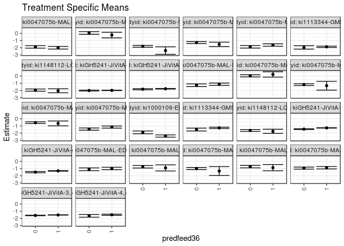

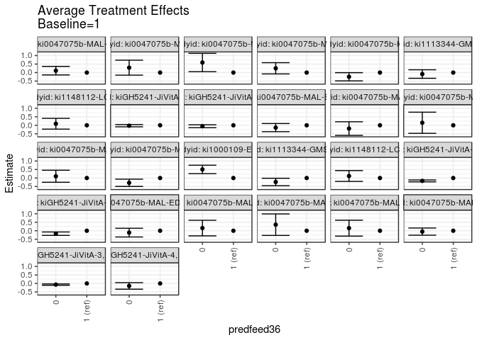

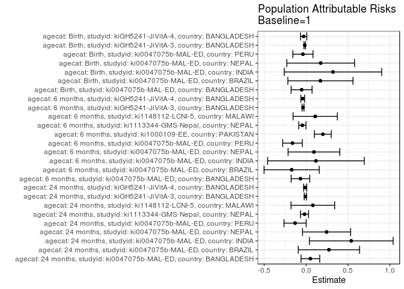

## Results Table

### Parameter: TSM

| agecat | studyid | country | intervention_level | baseline_level | estimate | ci_lower | ci_upper |
| --- | --- | --- | --- | --- | --- | --- | --- |
| Birth | ki0047075b-MAL-ED | BANGLADESH | 1 | NA | -0.9877426 | -1.1566021 | -0.8188830 |
| Birth | ki0047075b-MAL-ED | BANGLADESH | 0 | NA | -1.0985182 | -1.2923455 | -0.9046909 |
| Birth | ki0047075b-MAL-ED | BRAZIL | 1 | NA | -0.9057733 | -1.3302850 | -0.4812615 |
| Birth | ki0047075b-MAL-ED | BRAZIL | 0 | NA | -0.7487321 | -0.9197931 | -0.5776711 |
| Birth | ki0047075b-MAL-ED | INDIA | 1 | NA | -1.3440164 | -1.9584342 | -0.7295986 |
| Birth | ki0047075b-MAL-ED | INDIA | 0 | NA | -0.9882088 | -1.1323876 | -0.8440300 |
| Birth | ki0047075b-MAL-ED | NEPAL | 1 | NA | -0.8789370 | -1.3101436 | -0.4477303 |
| Birth | ki0047075b-MAL-ED | NEPAL | 0 | NA | -0.7268209 | -0.8982618 | -0.5553800 |
| Birth | ki0047075b-MAL-ED | PERU | 1 | NA | -0.8849511 | -1.0512715 | -0.7186307 |
| Birth | ki0047075b-MAL-ED | PERU | 0 | NA | -0.9352388 | -1.0789146 | -0.7915630 |
| Birth | kiGH5241-JiVitA-3 | BANGLADESH | 1 | NA | -1.5166508 | -1.5400483 | -1.4932534 |
| Birth | kiGH5241-JiVitA-3 | BANGLADESH | 0 | NA | -1.5847362 | -1.6239854 | -1.5454870 |
| Birth | kiGH5241-JiVitA-4 | BANGLADESH | 1 | NA | -1.4907519 | -1.5810511 | -1.4004527 |
| Birth | kiGH5241-JiVitA-4 | BANGLADESH | 0 | NA | -1.6357501 | -1.8215498 | -1.4499503 |
| 6 months | ki0047075b-MAL-ED | BANGLADESH | 1 | NA | -1.1330050 | -1.2891880 | -0.9768220 |
| 6 months | ki0047075b-MAL-ED | BANGLADESH | 0 | NA | -1.2686320 | -1.4501468 | -1.0871172 |
| 6 months | ki0047075b-MAL-ED | BRAZIL | 1 | NA | 0.2233447 | -0.1494344 | 0.5961237 |
| 6 months | ki0047075b-MAL-ED | BRAZIL | 0 | NA | 0.0311041 | -0.1222384 | 0.1844465 |
| 6 months | ki0047075b-MAL-ED | INDIA | 1 | NA | -1.3374720 | -1.9477713 | -0.7271727 |
| 6 months | ki0047075b-MAL-ED | INDIA | 0 | NA | -1.1873241 | -1.3051536 | -1.0694946 |
| 6 months | ki0047075b-MAL-ED | NEPAL | 1 | NA | -0.6545629 | -0.9887009 | -0.3204249 |
| 6 months | ki0047075b-MAL-ED | NEPAL | 0 | NA | -0.5502596 | -0.6702629 | -0.4302563 |
| 6 months | ki0047075b-MAL-ED | PERU | 1 | NA | -1.1546549 | -1.3010693 | -1.0082404 |
| 6 months | ki0047075b-MAL-ED | PERU | 0 | NA | -1.4364114 | -1.5907259 | -1.2820969 |
| 6 months | ki1000109-EE | PAKISTAN | 1 | NA | -2.4005912 | -2.5548779 | -2.2463046 |
| 6 months | ki1000109-EE | PAKISTAN | 0 | NA | -1.8951921 | -2.0896320 | -1.7007522 |
| 6 months | ki1113344-GMS-Nepal | NEPAL | 1 | NA | -1.2699738 | -1.3563915 | -1.1835561 |
| 6 months | ki1113344-GMS-Nepal | NEPAL | 0 | NA | -1.5026575 | -1.7034187 | -1.3018963 |
| 6 months | ki1148112-LCNI-5 | MALAWI | 1 | NA | -1.7481811 | -2.0392353 | -1.4571268 |
| 6 months | ki1148112-LCNI-5 | MALAWI | 0 | NA | -1.6285297 | -1.7598675 | -1.4971918 |
| 6 months | kiGH5241-JiVitA-3 | BANGLADESH | 1 | NA | -1.2753811 | -1.3018596 | -1.2489027 |
| 6 months | kiGH5241-JiVitA-3 | BANGLADESH | 0 | NA | -1.4444996 | -1.4959467 | -1.3930525 |
| 6 months | kiGH5241-JiVitA-4 | BANGLADESH | 1 | NA | -1.3195361 | -1.3618121 | -1.2772602 |
| 6 months | kiGH5241-JiVitA-4 | BANGLADESH | 0 | NA | -1.4925026 | -1.5854645 | -1.3995407 |
| 24 months | ki0047075b-MAL-ED | BANGLADESH | 1 | NA | -1.9870004 | -2.1694280 | -1.8045728 |
| 24 months | ki0047075b-MAL-ED | BANGLADESH | 0 | NA | -1.8749174 | -2.0472651 | -1.7025697 |
| 24 months | ki0047075b-MAL-ED | BRAZIL | 1 | NA | -0.2303791 | -0.6241082 | 0.1633500 |
| 24 months | ki0047075b-MAL-ED | BRAZIL | 0 | NA | 0.0573164 | -0.1304600 | 0.2450927 |
| 24 months | ki0047075b-MAL-ED | INDIA | 1 | NA | -2.3848290 | -2.9072333 | -1.8624247 |
| 24 months | ki0047075b-MAL-ED | INDIA | 0 | NA | -1.7937647 | -1.9221926 | -1.6653368 |
| 24 months | ki0047075b-MAL-ED | NEPAL | 1 | NA | -1.5197779 | -1.8226803 | -1.2168755 |
| 24 months | ki0047075b-MAL-ED | NEPAL | 0 | NA | -1.2688494 | -1.3982709 | -1.1394278 |
| 24 months | ki0047075b-MAL-ED | PERU | 1 | NA | -1.6115437 | -1.7802029 | -1.4428846 |
| 24 months | ki0047075b-MAL-ED | PERU | 0 | NA | -1.8589419 | -2.0299701 | -1.6879136 |
| 24 months | ki1113344-GMS-Nepal | NEPAL | 1 | NA | -1.8593359 | -1.9520524 | -1.7666194 |
| 24 months | ki1113344-GMS-Nepal | NEPAL | 0 | NA | -1.9451557 | -2.1774702 | -1.7128412 |
| 24 months | ki1148112-LCNI-5 | MALAWI | 1 | NA | -2.0408420 | -2.3150961 | -1.7665878 |
| 24 months | ki1148112-LCNI-5 | MALAWI | 0 | NA | -1.9495462 | -2.1064301 | -1.7926623 |
| 24 months | kiGH5241-JiVitA-3 | BANGLADESH | 1 | NA | -1.9854609 | -2.0173241 | -1.9535978 |
| 24 months | kiGH5241-JiVitA-3 | BANGLADESH | 0 | NA | -2.0087977 | -2.0725433 | -1.9450521 |
| 24 months | kiGH5241-JiVitA-4 | BANGLADESH | 1 | NA | -1.7651182 | -1.8086424 | -1.7215939 |
| 24 months | kiGH5241-JiVitA-4 | BANGLADESH | 0 | NA | -1.8207840 | -1.9003028 | -1.7412651 |

### Parameter: E(Y)

| agecat | studyid | country | intervention_level | baseline_level | estimate | ci_lower | ci_upper |
| --- | --- | --- | --- | --- | --- | --- | --- |
| Birth | ki0047075b-MAL-ED | BANGLADESH | NA | NA | -1.0414815 | -1.1687478 | -0.9142151 |
| Birth | ki0047075b-MAL-ED | BRAZIL | NA | NA | -0.7350811 | -0.8943683 | -0.5757938 |
| Birth | ki0047075b-MAL-ED | INDIA | NA | NA | -1.0235354 | -1.1657122 | -0.8813585 |
| Birth | ki0047075b-MAL-ED | NEPAL | NA | NA | -0.7052907 | -0.8627483 | -0.5478331 |
| Birth | ki0047075b-MAL-ED | PERU | NA | NA | -0.9231136 | -1.0355489 | -0.8106782 |
| Birth | kiGH5241-JiVitA-3 | BANGLADESH | NA | NA | -1.5333680 | -1.5553430 | -1.5113930 |
| Birth | kiGH5241-JiVitA-4 | BANGLADESH | NA | NA | -1.5200688 | -1.6064560 | -1.4336815 |
| 6 months | ki0047075b-MAL-ED | BANGLADESH | NA | NA | -1.2006806 | -1.3182323 | -1.0831288 |
| 6 months | ki0047075b-MAL-ED | BRAZIL | NA | NA | 0.0510207 | -0.0930194 | 0.1950608 |
| 6 months | ki0047075b-MAL-ED | INDIA | NA | NA | -1.2203672 | -1.3387619 | -1.1019726 |
| 6 months | ki0047075b-MAL-ED | NEPAL | NA | NA | -0.5610593 | -0.6737915 | -0.4483272 |
| 6 months | ki0047075b-MAL-ED | PERU | NA | NA | -1.3173678 | -1.4250795 | -1.2096560 |
| 6 months | ki1000109-EE | PAKISTAN | NA | NA | -2.2009401 | -2.3240630 | -2.0778171 |
| 6 months | ki1113344-GMS-Nepal | NEPAL | NA | NA | -1.3150063 | -1.3948049 | -1.2352077 |
| 6 months | ki1148112-LCNI-5 | MALAWI | NA | NA | -1.6395956 | -1.7592633 | -1.5199278 |
| 6 months | kiGH5241-JiVitA-3 | BANGLADESH | NA | NA | -1.3121772 | -1.3366725 | -1.2876819 |
| 6 months | kiGH5241-JiVitA-4 | BANGLADESH | NA | NA | -1.3602409 | -1.3996637 | -1.3208182 |
| 24 months | ki0047075b-MAL-ED | BANGLADESH | NA | NA | -1.9363270 | -2.0622735 | -1.8103806 |
| 24 months | ki0047075b-MAL-ED | BRAZIL | NA | NA | 0.0418343 | -0.1253834 | 0.2090521 |
| 24 months | ki0047075b-MAL-ED | INDIA | NA | NA | -1.8458150 | -1.9718703 | -1.7197596 |
| 24 months | ki0047075b-MAL-ED | NEPAL | NA | NA | -1.2752193 | -1.3954783 | -1.1549603 |
| 24 months | ki0047075b-MAL-ED | PERU | NA | NA | -1.7430000 | -1.8632412 | -1.6227588 |
| 24 months | ki1113344-GMS-Nepal | NEPAL | NA | NA | -1.8785563 | -1.9657607 | -1.7913519 |
| 24 months | ki1148112-LCNI-5 | MALAWI | NA | NA | -1.9605820 | -2.1001715 | -1.8209925 |
| 24 months | kiGH5241-JiVitA-3 | BANGLADESH | NA | NA | -1.9946153 | -2.0246928 | -1.9645378 |
| 24 months | kiGH5241-JiVitA-4 | BANGLADESH | NA | NA | -1.7766542 | -1.8163158 | -1.7369927 |

### Parameter: ATE

| agecat | studyid | country | intervention_level | baseline_level | estimate | ci_lower | ci_upper |
| --- | --- | --- | --- | --- | --- | --- | --- |
| Birth | ki0047075b-MAL-ED | BANGLADESH | 1 | 1 | 0.0000000 | 0.0000000 | 0.0000000 |
| Birth | ki0047075b-MAL-ED | BANGLADESH | 0 | 1 | -0.1107756 | -0.3682250 | 0.1466737 |
| Birth | ki0047075b-MAL-ED | BRAZIL | 1 | 1 | 0.0000000 | 0.0000000 | 0.0000000 |
| Birth | ki0047075b-MAL-ED | BRAZIL | 0 | 1 | 0.1570411 | -0.3024662 | 0.6165485 |
| Birth | ki0047075b-MAL-ED | INDIA | 1 | 1 | 0.0000000 | 0.0000000 | 0.0000000 |
| Birth | ki0047075b-MAL-ED | INDIA | 0 | 1 | 0.3558076 | -0.2758117 | 0.9874269 |
| Birth | ki0047075b-MAL-ED | NEPAL | 1 | 1 | 0.0000000 | 0.0000000 | 0.0000000 |
| Birth | ki0047075b-MAL-ED | NEPAL | 0 | 1 | 0.1521161 | -0.3157467 | 0.6199788 |
| Birth | ki0047075b-MAL-ED | PERU | 1 | 1 | 0.0000000 | 0.0000000 | 0.0000000 |
| Birth | ki0047075b-MAL-ED | PERU | 0 | 1 | -0.0502877 | -0.2616569 | 0.1610816 |
| Birth | kiGH5241-JiVitA-3 | BANGLADESH | 1 | 1 | 0.0000000 | 0.0000000 | 0.0000000 |
| Birth | kiGH5241-JiVitA-3 | BANGLADESH | 0 | 1 | -0.0680853 | -0.1086780 | -0.0274927 |
| Birth | kiGH5241-JiVitA-4 | BANGLADESH | 1 | 1 | 0.0000000 | 0.0000000 | 0.0000000 |
| Birth | kiGH5241-JiVitA-4 | BANGLADESH | 0 | 1 | -0.1449982 | -0.3371431 | 0.0471468 |
| 6 months | ki0047075b-MAL-ED | BANGLADESH | 1 | 1 | 0.0000000 | 0.0000000 | 0.0000000 |
| 6 months | ki0047075b-MAL-ED | BANGLADESH | 0 | 1 | -0.1356270 | -0.3757785 | 0.1045245 |
| 6 months | ki0047075b-MAL-ED | BRAZIL | 1 | 1 | 0.0000000 | 0.0000000 | 0.0000000 |
| 6 months | ki0047075b-MAL-ED | BRAZIL | 0 | 1 | -0.1922406 | -0.5926492 | 0.2081681 |
| 6 months | ki0047075b-MAL-ED | INDIA | 1 | 1 | 0.0000000 | 0.0000000 | 0.0000000 |
| 6 months | ki0047075b-MAL-ED | INDIA | 0 | 1 | 0.1501479 | -0.4721826 | 0.7724783 |
| 6 months | ki0047075b-MAL-ED | NEPAL | 1 | 1 | 0.0000000 | 0.0000000 | 0.0000000 |
| 6 months | ki0047075b-MAL-ED | NEPAL | 0 | 1 | 0.1043033 | -0.2505575 | 0.4591640 |
| 6 months | ki0047075b-MAL-ED | PERU | 1 | 1 | 0.0000000 | 0.0000000 | 0.0000000 |
| 6 months | ki0047075b-MAL-ED | PERU | 0 | 1 | -0.2817565 | -0.4953680 | -0.0681451 |
| 6 months | ki1000109-EE | PAKISTAN | 1 | 1 | 0.0000000 | 0.0000000 | 0.0000000 |
| 6 months | ki1000109-EE | PAKISTAN | 0 | 1 | 0.5053992 | 0.2569698 | 0.7538285 |
| 6 months | ki1113344-GMS-Nepal | NEPAL | 1 | 1 | 0.0000000 | 0.0000000 | 0.0000000 |
| 6 months | ki1113344-GMS-Nepal | NEPAL | 0 | 1 | -0.2326837 | -0.4512795 | -0.0140880 |
| 6 months | ki1148112-LCNI-5 | MALAWI | 1 | 1 | 0.0000000 | 0.0000000 | 0.0000000 |
| 6 months | ki1148112-LCNI-5 | MALAWI | 0 | 1 | 0.1196514 | -0.1988184 | 0.4381212 |
| 6 months | kiGH5241-JiVitA-3 | BANGLADESH | 1 | 1 | 0.0000000 | 0.0000000 | 0.0000000 |
| 6 months | kiGH5241-JiVitA-3 | BANGLADESH | 0 | 1 | -0.1691185 | -0.2236128 | -0.1146242 |
| 6 months | kiGH5241-JiVitA-4 | BANGLADESH | 1 | 1 | 0.0000000 | 0.0000000 | 0.0000000 |
| 6 months | kiGH5241-JiVitA-4 | BANGLADESH | 0 | 1 | -0.1729665 | -0.2732914 | -0.0726416 |
| 24 months | ki0047075b-MAL-ED | BANGLADESH | 1 | 1 | 0.0000000 | 0.0000000 | 0.0000000 |
| 24 months | ki0047075b-MAL-ED | BANGLADESH | 0 | 1 | 0.1120830 | -0.1395068 | 0.3636727 |
| 24 months | ki0047075b-MAL-ED | BRAZIL | 1 | 1 | 0.0000000 | 0.0000000 | 0.0000000 |
| 24 months | ki0047075b-MAL-ED | BRAZIL | 0 | 1 | 0.2876955 | -0.1527636 | 0.7281545 |
| 24 months | ki0047075b-MAL-ED | INDIA | 1 | 1 | 0.0000000 | 0.0000000 | 0.0000000 |
| 24 months | ki0047075b-MAL-ED | INDIA | 0 | 1 | 0.5910643 | 0.0537129 | 1.1284156 |
| 24 months | ki0047075b-MAL-ED | NEPAL | 1 | 1 | 0.0000000 | 0.0000000 | 0.0000000 |
| 24 months | ki0047075b-MAL-ED | NEPAL | 0 | 1 | 0.2509285 | -0.0794080 | 0.5812650 |
| 24 months | ki0047075b-MAL-ED | PERU | 1 | 1 | 0.0000000 | 0.0000000 | 0.0000000 |
| 24 months | ki0047075b-MAL-ED | PERU | 0 | 1 | -0.2473982 | -0.4888568 | -0.0059395 |
| 24 months | ki1113344-GMS-Nepal | NEPAL | 1 | 1 | 0.0000000 | 0.0000000 | 0.0000000 |
| 24 months | ki1113344-GMS-Nepal | NEPAL | 0 | 1 | -0.0858198 | -0.3360974 | 0.1644578 |
| 24 months | ki1148112-LCNI-5 | MALAWI | 1 | 1 | 0.0000000 | 0.0000000 | 0.0000000 |
| 24 months | ki1148112-LCNI-5 | MALAWI | 0 | 1 | 0.0912958 | -0.2256909 | 0.4082824 |
| 24 months | kiGH5241-JiVitA-3 | BANGLADESH | 1 | 1 | 0.0000000 | 0.0000000 | 0.0000000 |
| 24 months | kiGH5241-JiVitA-3 | BANGLADESH | 0 | 1 | -0.0233367 | -0.0902626 | 0.0435891 |
| 24 months | kiGH5241-JiVitA-4 | BANGLADESH | 1 | 1 | 0.0000000 | 0.0000000 | 0.0000000 |
| 24 months | kiGH5241-JiVitA-4 | BANGLADESH | 0 | 1 | -0.0556658 | -0.1414492 | 0.0301176 |

### Parameter: PAR

| agecat | studyid | country | intervention_level | baseline_level | estimate | ci_lower | ci_upper |
| --- | --- | --- | --- | --- | --- | --- | --- |
| Birth | ki0047075b-MAL-ED | BANGLADESH | 1 | NA | -0.0537389 | -0.1785638 | 0.0710859 |
| Birth | ki0047075b-MAL-ED | BRAZIL | 1 | NA | 0.1706922 | -0.2180723 | 0.5594567 |
| Birth | ki0047075b-MAL-ED | INDIA | 1 | NA | 0.3204811 | -0.2612829 | 0.9022450 |
| Birth | ki0047075b-MAL-ED | NEPAL | 1 | NA | 0.1736463 | -0.2306686 | 0.5779612 |
| Birth | ki0047075b-MAL-ED | PERU | 1 | NA | -0.0381624 | -0.1587458 | 0.0824209 |
| Birth | kiGH5241-JiVitA-3 | BANGLADESH | 1 | NA | -0.0167172 | -0.0255746 | -0.0078597 |
| Birth | kiGH5241-JiVitA-4 | BANGLADESH | 1 | NA | -0.0293168 | -0.0670785 | 0.0084448 |
| 6 months | ki0047075b-MAL-ED | BANGLADESH | 1 | NA | -0.0676756 | -0.1784379 | 0.0430867 |
| 6 months | ki0047075b-MAL-ED | BRAZIL | 1 | NA | -0.1723239 | -0.5018122 | 0.1571644 |
| 6 months | ki0047075b-MAL-ED | INDIA | 1 | NA | 0.1171048 | -0.4602746 | 0.6944841 |
| 6 months | ki0047075b-MAL-ED | NEPAL | 1 | NA | 0.0935036 | -0.2151527 | 0.4021599 |
| 6 months | ki0047075b-MAL-ED | PERU | 1 | NA | -0.1627129 | -0.2791821 | -0.0462437 |
| 6 months | ki1000109-EE | PAKISTAN | 1 | NA | 0.1996512 | 0.0989536 | 0.3003487 |
| 6 months | ki1113344-GMS-Nepal | NEPAL | 1 | NA | -0.0450326 | -0.0878615 | -0.0022036 |
| 6 months | ki1148112-LCNI-5 | MALAWI | 1 | NA | 0.1085855 | -0.1556433 | 0.3728143 |
| 6 months | kiGH5241-JiVitA-3 | BANGLADESH | 1 | NA | -0.0367961 | -0.0482497 | -0.0253424 |
| 6 months | kiGH5241-JiVitA-4 | BANGLADESH | 1 | NA | -0.0407048 | -0.0629603 | -0.0184494 |
| 24 months | ki0047075b-MAL-ED | BANGLADESH | 1 | NA | 0.0506733 | -0.0611495 | 0.1624962 |
| 24 months | ki0047075b-MAL-ED | BRAZIL | 1 | NA | 0.2722134 | -0.0937824 | 0.6382092 |
| 24 months | ki0047075b-MAL-ED | INDIA | 1 | NA | 0.5390140 | 0.0389442 | 1.0390838 |
| 24 months | ki0047075b-MAL-ED | NEPAL | 1 | NA | 0.2445586 | -0.0426704 | 0.5317875 |
| 24 months | ki0047075b-MAL-ED | PERU | 1 | NA | -0.1314563 | -0.2640640 | 0.0011514 |
| 24 months | ki1113344-GMS-Nepal | NEPAL | 1 | NA | -0.0192204 | -0.0678755 | 0.0294348 |
| 24 months | ki1148112-LCNI-5 | MALAWI | 1 | NA | 0.0802599 | -0.1803225 | 0.3408424 |
| 24 months | kiGH5241-JiVitA-3 | BANGLADESH | 1 | NA | -0.0091543 | -0.0230775 | 0.0047689 |
| 24 months | kiGH5241-JiVitA-4 | BANGLADESH | 1 | NA | -0.0115361 | -0.0302600 | 0.0071878 |